# Inference for numerical data

Jack Wright

2020-10-18

```r
library(tidyverse)
library(openintro)
library(infer)
```

### Exercise 1

The cases are about 13583 school aged children. Remember that you can answer this question by viewing the data in the data viewer or by using the following command:

```r
data(yrbss)
```

### Exercise 2

1. How many observations are we missing weights from?

```r
summary(yrbss$weight)
```

```
##    Min. 1st Qu.  Median    Mean 3rd Qu.    Max.    NA's
##   29.94   56.25   64.41   67.91   76.20  180.99    1004
```

```r
yrbss%>%
  filter(is.na(weight))%>%
  nrow()
```

```
## [1] 1004
```

1004 cases are missing weights.

```r
yrbss <- yrbss %>%
  mutate(physical_3plus = ifelse(yrbss$physically_active_7d > 2, "yes", "no"))
```

### Exercise 3

1. Make a side-by-side boxplot of `physical_3plus` and `weight`. Is there a relationship between these two variables? What did you expect and why?

They look very similar. I was expecting people who were physical 3 times a week to weigh less on average but the medians look similar as well as the IQR.

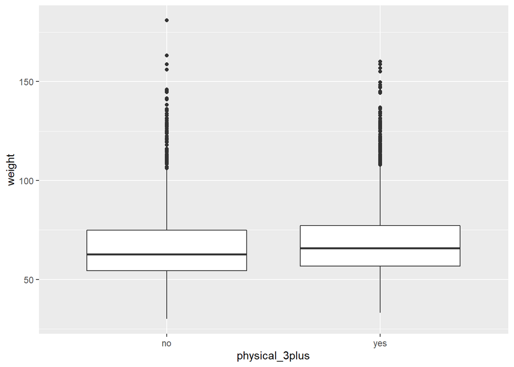

```r
yrbss$physical_3plus<-as.factor(yrbss$physical_3plus)
yrb_plot<-yrbss%>%
  filter(!is.na(weight),!is.na(physical_3plus))
p<-ggplot(yrb_plot, aes(x=physical_3plus,y=weight))+
  geom_boxplot()
p
```

```r
yrbss %>%
  group_by(physical_3plus) %>%
  summarise(mean_weight = mean(weight, na.rm = TRUE))
```

```
## # A tibble: 3 x 2
##   physical_3plus mean_weight
##   <fct>                <dbl>
## 1 no                    66.7
## 2 yes                   68.4
## 3 <NA>                  69.9
```

### Exercise 4

1. Are all conditions necessary for inference satisfied? Comment on each. You can compute the group sizes with the `summarize` command above by defining a new variable with the definition `n()`

CONDITIONS FOR INFERENCE:

Independence:

it was a SRS and the two groups are not linked, necessarily one who excersizes 3 times a week plus cannot be in the group that doesn’t.

Size:

the groups are less than 10% of the total population of kids who excersize and those who don’t

in the study…

```r
#create new variable n

yrbss<- yrbss %>%
  mutate(n = ifelse(yrbss$physically_active_7d > 2, "yes", "no"))

yrbss$n<-as.factor(yrbss$n)

view(yrbss)
yrbss%>%
 count(n)
```

```
## Storing counts in `nn`, as `n` already present in input
## i Use `name = "new_name"` to pick a new name.
```

```
## # A tibble: 3 x 2
##   n        nn
##   <fct> <int>
## 1 no     4404
## 2 yes    8906
## 3 <NA>    273
```

### Exercise 5

Hypothesis test:

H_0: the difference in the means between physical 3 plus and less than 3 are equal (mean1-mean2)=0 H_A: the weights are diffferent !=0

```r
obs_diff <- yrbss %>%
  specify(weight ~ physical_3plus) %>%
  calculate(stat = "diff in means", order = c("yes", "no"))
null_dist <- yrbss %>%
  specify(weight ~ physical_3plus) %>%
  hypothesize(null = "independence") %>%
  generate(reps = 1000, type = "permute") %>%
  calculate(stat = "diff in means", order = c("yes", "no"))
```

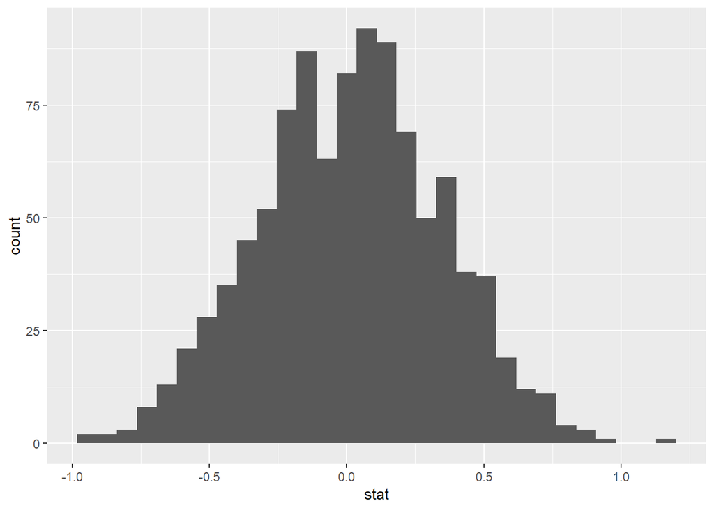

```r
ggplot(data = null_dist, aes(x = stat)) +
  geom_histogram()
```

[figure not shown]

```r
ggplot(data = null_dist, aes(x = stat)) +
  geom_histogram()
```

### Exercise 6

How many of these null permutations have a difference of at least obs_stat?

```r
obs_diff_val<-obs_diff$stat[1]

null_list<-as.list(null_dist$stat)
null_abs<-lapply(null_list, FUN=function(x){abs(x)})

null_dist%>%
  summarise(mean= mean(stat, na.rm=TRUE))
```

```
## # A tibble: 1 x 1
##     mean
##    <dbl>
## 1 0.0153
```

```r
null_dist%>%
  filter(stat>obs_diff_val)
```

```
## # A tibble: 0 x 2
## # ... with 2 variables: replicate <int>, stat <dbl>
```

none of the values are greater than the obs_diff_val

```r
null_dist %>%
  get_p_value(obs_stat = obs_diff, direction = "two_sided")
```

```
## # A tibble: 1 x 1
##   p_value
##     <dbl>
## 1       0
```

### Exercise 7

Construct and record a confidence interval for the difference between the weights of those who exercise at least three times a week and those who don’t, and interpret this interval in context of the data.

```r
# number of groups
n_1<-8406
n_2<-4408

x_bar_diff<-1.78
T_score<-pt(.025,4407,lower.tail = FALSE)*2

#get sigmas of samples
sigma_1<-yrbss %>%
  group_by(physical_3plus) %>%
  summarise(sd = sd(weight, na.rm = TRUE))%>%
  filter(physical_3plus=="yes")%>%
  select(sd)%>%
  as.double()
sigma_2<-yrbss %>%
  group_by(physical_3plus) %>%
  summarise(sd = sd(weight, na.rm = TRUE))%>%
  filter(physical_3plus=="no")%>%
  select(sd)%>%
  as.double()
SE<-sqrt((sigma_1^2 /n_1)+(sigma_2^2/n_2))

bot<-x_bar_diff-T_score*SE
top<-x_bar_diff+T_score*SE

cat("the 95% confidence interval for comparing the differnece between the means of these two independent samples is ",bot,"to",top)
```

```
## the 95% confidence interval for comparing the differnece between the means of these two independent samples is  1.465649 to 2.094351
```

I am not sure I fully understand the role of the null distribution that we calculated. This is a little backwards than I thought it would work but, maybe we can say, since H_0: there is NO difference bewteen the two groups falls OUTSIDE our 95% confidence interval, we can REJECT the null hypothesis.

### Exercise 8

Calculate a 95% confidence interval for the average height in meters (height) and interpret it in context.

Explore height

```r
summary(yrbss$height)
```

```
##    Min. 1st Qu.  Median    Mean 3rd Qu.    Max.    NA's
##   1.270   1.600   1.680   1.691   1.780   2.110    1004
```

```r
height<-yrbss%>%
  filter(!is.na(height))%>%
  select(height)

n<-nrow(height)
df<-n-1
height<-height$height


x_bar<-mean(height)
sigma<-sd(height)
SE<-sigma/sqrt(n)
t_star<-qt(.025,df=df)

#confidence interval

bot<-x_bar-abs(t_star*SE)
top<-x_bar+abs(t_star*SE)

cat("the 95% confidence interval is ",bot," to ",top)
```

```
## the 95% confidence interval is  1.689411  to  1.693071
```

```r
t_star<-abs(qt(.05,df=df))
# the rest is the same
x_bar<-mean(height)
sigma<-sd(height)
SE<-sigma/sqrt(n)
bot_1<-x_bar-abs(t_star*SE)
top_1<-x_bar+abs(t_star*SE)

cat("the 90% confidence interval is ",bot_1," to ",top_1)
```

```
## the 90% confidence interval is  1.689705  to  1.692777
```

The difference is so slight, could this be due to the really tight standard error due to the sample size?

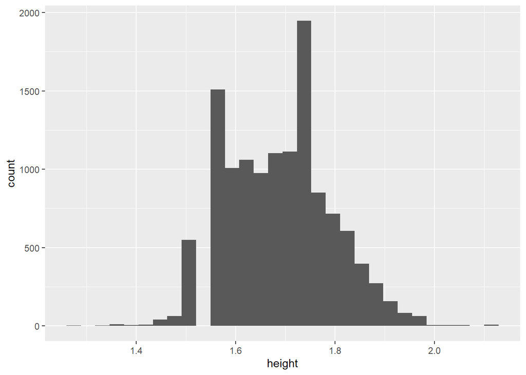

```r
yrbss<-as.data.frame(yrbss)
ggplot(yrbss, aes(x=height))+
  geom_histogram()
```

### Exercise 10

Conduct a hypothesis test evaluating whether the average height is DIFFERENT for those who exercise at least three times a week and those who dont.

```r
obs_diff <- yrbss %>%
  specify(height ~ physical_3plus) %>%
  calculate(stat = "diff in means", order = c("yes", "no"))
```

hypothesis test:

H_0: the difference in the height for the two groups is zero

(mean_diff=0)

H_A: the difference in heights is NOT zero

(mean_diff!=0)

```r
#physically active count
n_1<-yrbss%>%
  filter(physical_3plus=="yes")%>%
  nrow()
n_2<-yrbss%>%
  filter(physical_3plus=="no")%>%
  nrow()
#difference in mean height
obs_diff <- yrbss %>%
  specify(height ~ physical_3plus) %>%
  calculate(stat = "diff in means", order = c("yes", "no"))
null<-0
#sd for physically active
sigma_1<-yrbss %>%
  group_by(physical_3plus) %>%
  summarise(sd = sd(height, na.rm = TRUE))%>%
  filter(physical_3plus=="yes")%>%
  select(sd)%>%
  as.double()
#sd for not physically active
sigma_2<-yrbss %>%
  group_by(physical_3plus) %>%
  summarise(sd = sd(height, na.rm = TRUE))%>%
  filter(physical_3plus=="no")%>%
  select(sd)%>%
  as.double()
#standard error
SE<-sqrt((sigma_1^2 /n_1)+(sigma_2^2/n_2))
T_score<-abs(qt(.025,4407))

bot<-x_bar_diff-T_score*SE
top<-x_bar_diff+T_score*SE

cat("the 95% confidence interval for the difference in mean height between physically active and non physically active is ",bot,"to",top)
```

```
## the 95% confidence interval for the difference in mean height between physically active and non physically active is  1.77628 to 1.78372
```

### Exercise 11

Now, a non-inference task: Determine the number of different options there are in the dataset for the hours_tv_per_school_day there are.

```r
yrbss%>%
  filter(!is.na(hours_tv_per_school_day))%>%
  select(hours_tv_per_school_day)%>%
  unique()
```

```
##    hours_tv_per_school_day
## 1                       5+
## 4                        2
## 5                        3
## 10            do not watch
## 12                      <1
## 14                       4
## 19                       1
```

### Exercise 12

Come up with a research question evaluating the relationship between height or weight and sleep. Formulate the question in a way that it can be answered using a hypothesis test and/or a confidence interval. Report the statistical results, and also provide an explanation in plain language. Be sure to check all assumptions, state your α level, and conclude in context.

Exploring data:

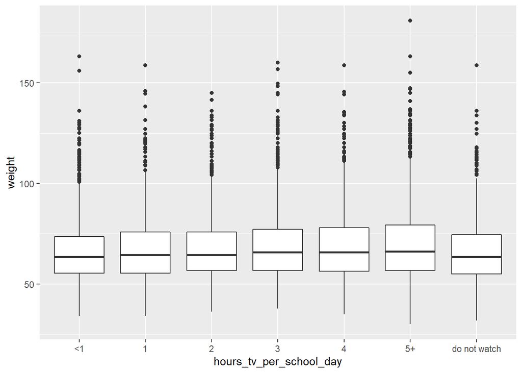

```r
yrbss$hours_tv_per_school_day<-as.factor(yrbss$hours_tv_per_school_day)
yrb_plot<-yrbss%>%
  filter(!is.na(weight),!is.na(hours_tv_per_school_day))
p<-ggplot(yrb_plot, aes(x=hours_tv_per_school_day,y=weight))+
  geom_boxplot()
p
```

looking at the box plots, it looks like there is no major difference between weight and how much TV one watches.

I would like to do an ANOVA test on this data:

CHECKS:

Normality:

the sample sizes are large enough that the skew can be overlooked.

Homogeneity of variance:

the IQR for the categories looks similar across groups.

```r
library(psych)
desc<-describeBy(yrbss$weight,yrbss$hours_tv_per_school_day,mat=TRUE)

print(desc,row.names=FALSE)
```

```
##  item       group1 vars    n     mean       sd median  trimmed      mad   min
##     1           <1    1 2021 66.48461 15.70216  63.50 64.68001 13.44718 34.02
##     2            1    1 1667 67.37800 16.37220  64.41 65.69415 14.79635 34.02
##     3            2    1 2548 67.78624 16.42145  64.41 66.06289 14.79635 36.29
##     4            3    1 1995 69.03978 17.35373  65.77 67.15432 14.79635 37.65
##     5            4    1  976 68.90626 18.02983  65.77 67.02081 16.81268 34.93
##     6           5+    1 1430 70.20328 19.25428  66.23 67.80165 16.13069 29.94
##     7 do not watch    1 1671 66.26614 15.75067  63.50 64.52085 13.44718 31.75
##     max  range     skew kurtosis        se
##  163.30 129.28 1.304176 2.665420 0.3492821
##  158.76 124.74 1.137777 1.955114 0.4009952
##  145.15 108.86 1.094115 1.497159 0.3253208
##  160.12 122.47 1.252392 2.329786 0.3885271
##  158.76 123.83 1.166745 1.828749 0.5771208
##  180.99 151.05 1.318850 2.351653 0.5091658
##  158.76 127.01 1.258166 2.409482 0.3853104
```

perform ANOVA test:

```r
aov.out<-aov(weight ~ hours_tv_per_school_day, data=yrbss)

summary(aov.out)
```

```
##                            Df  Sum Sq Mean Sq F value  Pr(>F)
## hours_tv_per_school_day     6   20160    3360   11.83 2.8e-13 ***
## Residuals               12301 3492964     284
## ---
## Signif. codes:  0 '***' 0.001 '**' 0.01 '*' 0.05 '.' 0.1 ' ' 1
## 1275 observations deleted due to missingness
```

The p-value is very small so it looks like there is some effect, but we cannot yet say which group.

NEXT STEPS:

we want to do a t test of each pair, with a Bonferroni adjustment to the alpha.

```r
#T_score<-(x_bar_middle-x_bar_lower) - null / SE (for comparisons)
n_five<-1430
n_three<-1995
x_bar_five<-70.20328
x_bar_three<-67.78624
#from the residuals
MSE<-284
null<-0
SE<-sqrt((MSE/n_five)+(MSE/n_three))
T_score<-((x_bar_five-x_bar_three)-null)/SE
df=12301
k<-7
K<-(k*(k-1))/2
a<-.05
(a_star<-a/K)
```

```
## [1] 0.002380952
```

use R to get the area under the curve of the t-distribution

```r
p_value<-2*pt(T_score,df=df,lower.tail = FALSE)
```

recall we are using the MODIFIED significance level a*

```r
print(a_star)
```

```
## [1] 0.002380952
```

```r
print(p_value)
```

```
## [1] 3.50588e-05
```